## # Lab3 Answers File

## Please write your answers into the space below the questions. Knit this file when you are done to check that all code runs. Remember to rename the file to contain *your actual* Last and First name and **submit both the Rmd and Html file to canvas**.

#### Amatullah Mir

**1.1**

```r
protein_DataVec <- read.csv("protein_data.csv", header = TRUE, stringsAsFactors = FALSE)
protein_Data <- protein_DataVec$length


mean(protein_DataVec$length)
```

```
## [1] 545.3942
```

```r
range(protein_DataVec$length)
```

```
## [1]   40 9900
```

```r
sd(protein_DataVec$length)
```

```
## [1] 594.6286
```

```r
# Funky Sampler Code for Use in 1.2
funkySampler <- function(dataset, size, n){
    results <- numeric(n)
    for(i in 1:n){
        vectorSample <- sample(dataset, size)
        results[i] <- mean(vectorSample)
    }
    return(results)
}
```

**1.2**

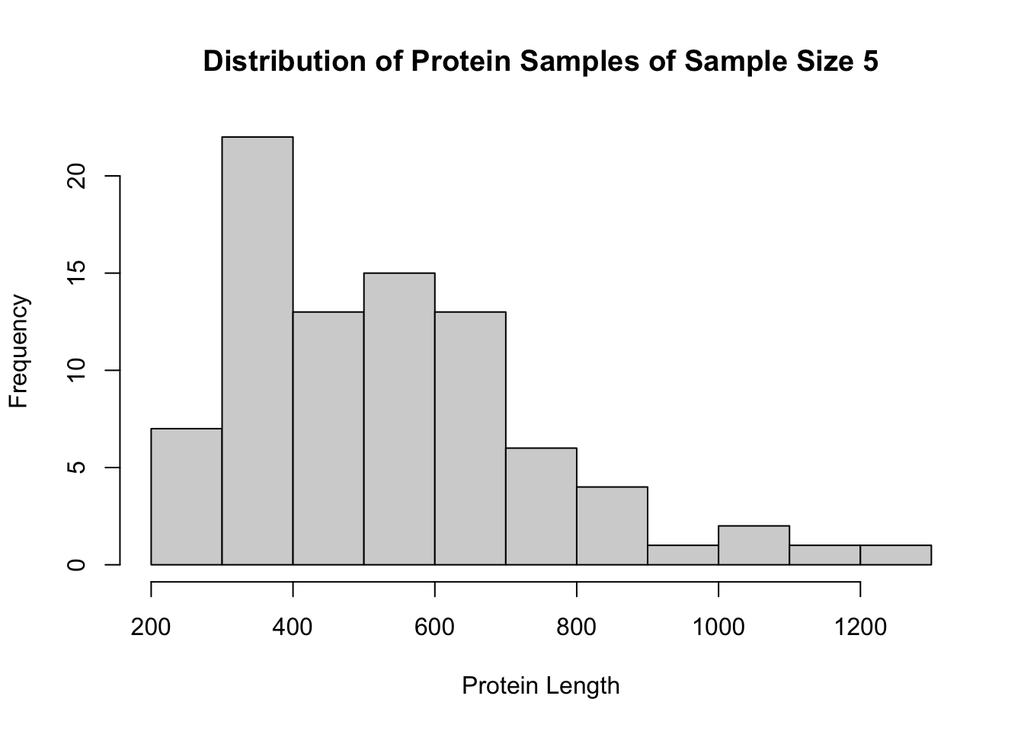

```r
samp5 <- funkySampler(protein_Data, 5, 85)
samp15 <- funkySampler(protein_Data, 15, 85)
samp150 <- funkySampler(protein_Data, 150, 85)
samp1500 <- funkySampler(protein_Data, 1500, 85)

hist(samp5, xlab="Protein Length", main="Distribution of Protein Samples of Sample Size 5")
```

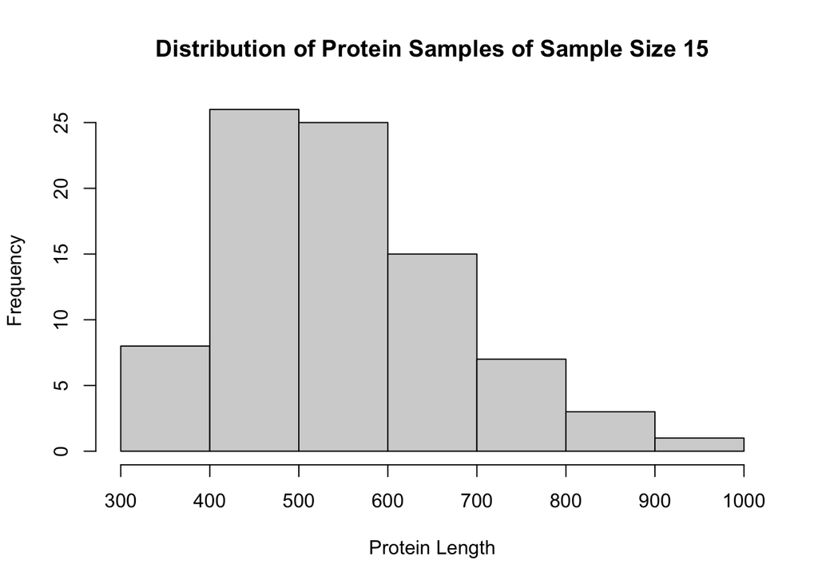

```r
hist(samp15, xlab="Protein Length", main="Distribution of Protein Samples of Sample Size 15")
```

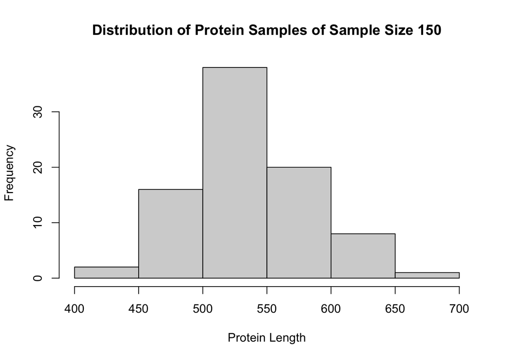

```r
hist(samp150, xlab="Protein Length", main="Distribution of Protein Samples of Sample Size 150")
```

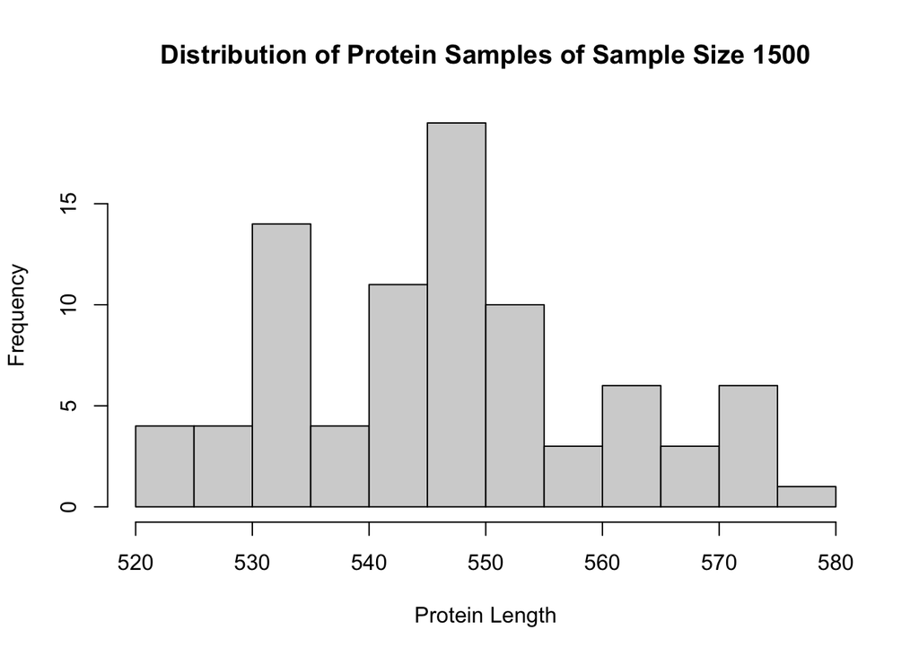

```r
hist(samp1500, xlab="Protein Length", main="Distribution of Protein Samples of Sample Size 1500")
```

**1.3** As the sample size increases, the graphs appear more and more normally distributed/Gaussian.

**1.4** The mean, which is calculated to be 545.3942, seems to be the mean for the sample size of 1500. The larger sample size has the closest approximation to the true mean.

**1.5**

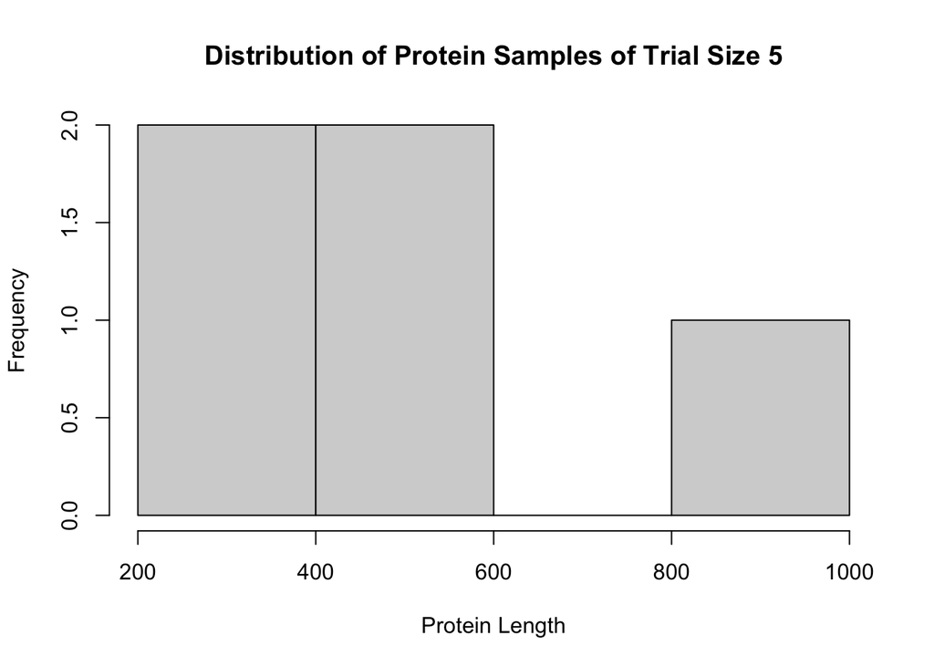

```r
samp5_ <- funkySampler(protein_Data, 7, 5)
samp15_ <- funkySampler(protein_Data, 7, 15)
samp150_ <- funkySampler(protein_Data, 7, 150)
samp1500_ <- funkySampler(protein_Data, 7, 1500)

hist(samp5_, xlab="Protein Length", main="Distribution of Protein Samples of Trial Size 5")
```

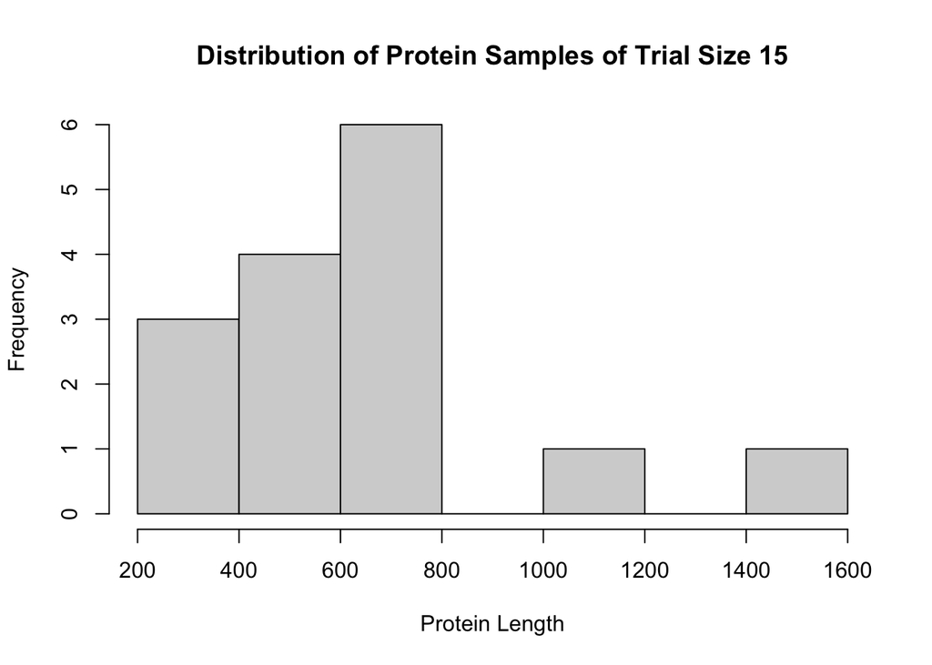

```r
hist(samp15_, xlab="Protein Length", main="Distribution of Protein Samples of Trial Size 15")
```

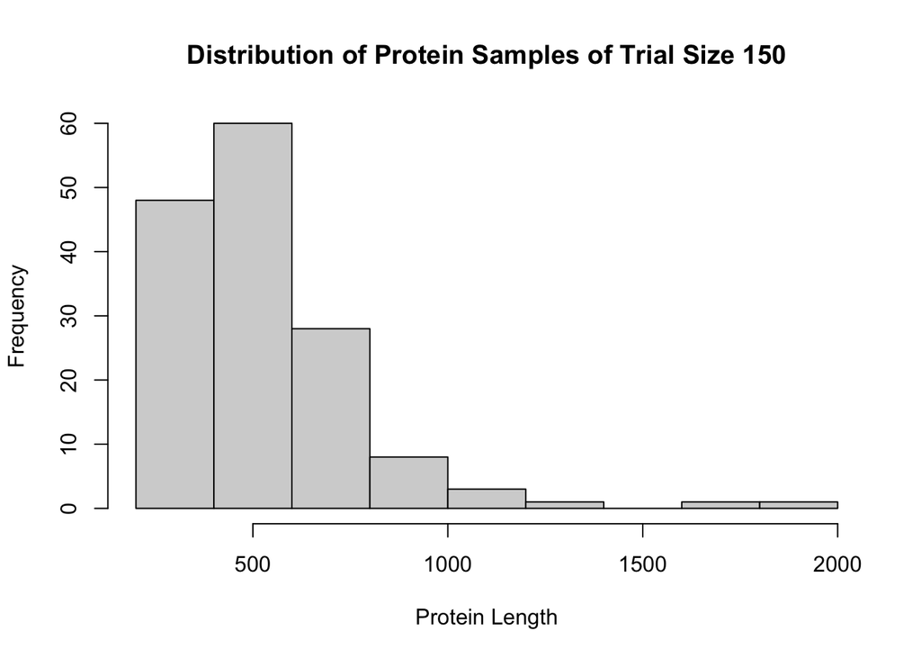

```r
hist(samp150_, xlab="Protein Length", main="Distribution of Protein Samples of Trial Size 150")
```

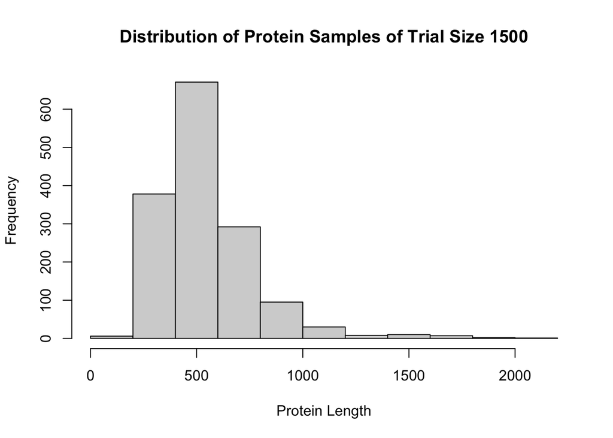

```r
hist(samp1500_, xlab="Protein Length", main="Distribution of Protein Samples of Trial Size 1500")
```

As the number of trials increases, the graph appears increasingly positively skewed.

```r
# If you haven't installed seqinr yet then uncomment the line below this
#install.packages('seqinr')
library('seqinr')
dengue <- read.fasta(file = 'dengue_seq.txt')
dengue_vec <- as.vector(dengue[[1]])
```

**1.6 (a)**

```r
library('seqinr')
dengue <- read.fasta(file = 'dengue_seq.txt')
dengue_vec <- as.vector(dengue[[1]])

GC_content <- function(seq){
  length <- 0
  c <- 0
  g <- 0

for(i in seq){
  length <- length + 1
  if(i=="c"){
    c <- c+1
  }
  if(i=="g"){
    g <- g+1
  }
}
  GC_content <- ((g+c)/length)*100
  return(GC_content)
}

findGC <- function(dataset, size, n){
    results <- numeric(n)
    for(i in 1:n){
        vectorSample <- sample(dataset, size)
        results[i] <- GC_content(vectorSample)
    }
    return(results)
}


findGC(dengue_vec, 100, 10)
```

```
##  [1] 44 50 45 58 43 50 51 49 50 46
```

**1.6 (b)**

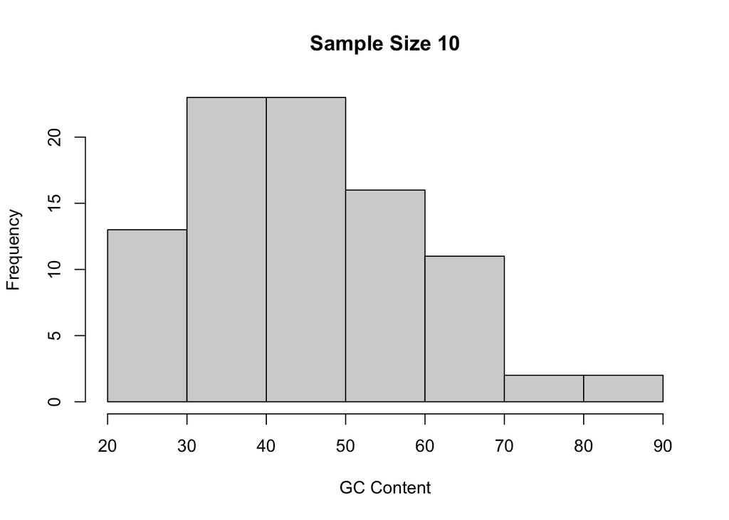

```r
w <- findGC(dengue_vec, 10, 90)
x <- findGC(dengue_vec, 100, 90)
y <- findGC(dengue_vec, 1000, 90)
z <- findGC(dengue_vec, 10000, 90)

hist(w, xlab="GC Content", main="Sample Size 10")
```

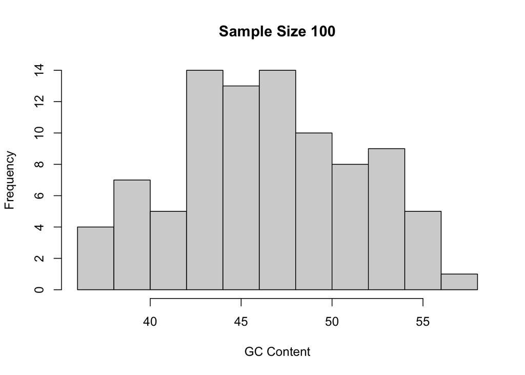

```r
hist(x, xlab="GC Content", main="Sample Size 100")
```

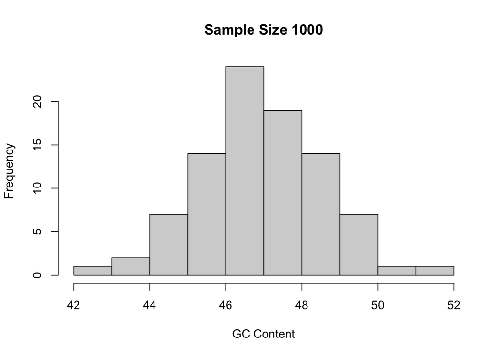

```r
hist(y, xlab="GC Content", main="Sample Size 1000")
```

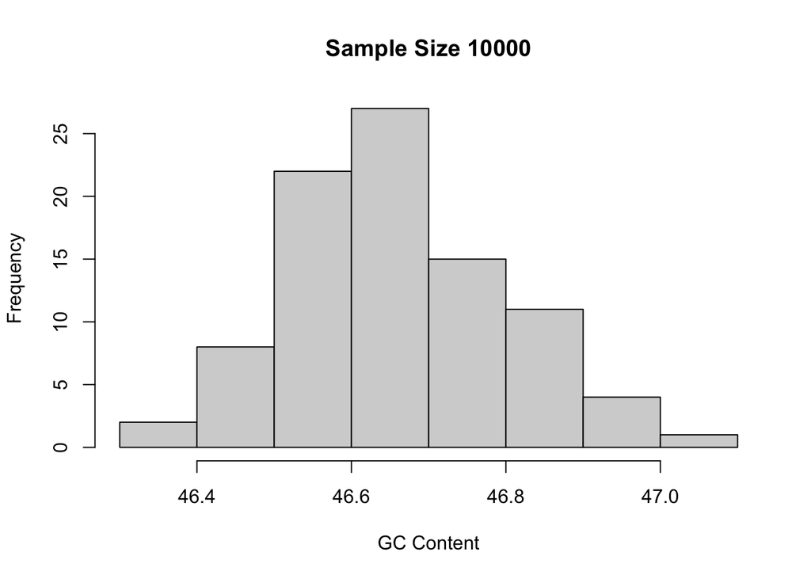

```r
hist(z, xlab="GC Content", main="Sample Size 10000")
```

**1.6 (c)** The larger the sample size, the closer the mean came to the true GC content, which is around 46.7.

**2.1**

```r
sd(samp5)
```

```
## [1] 212.8657
```

```r
sd(samp15)
```

```
## [1] 126.8995
```

```r
sd(samp150)
```

```
## [1] 48.40165
```

```r
sd(samp1500)
```

```
## [1] 13.74937
```

```r
sd(samp5_)
```

```
## [1] 249.5814
```

```r
sd(samp15_)
```

```
## [1] 311.9083
```

```r
sd(samp150_)
```

```
## [1] 243.2242
```

```r
sd(samp1500_)
```

```
## [1] 227.7602
```

```r
# the sample size matters more for precision, because the distributions of the standard deviations of the samples who had a greater sample size seems to be more similar to one another in comparison to the distributions of the samples with more trials..
```

**2.2**

```r
SE <- function(input)
  return(sd(input)/(sqrt(length(input))))
```

**2.3**

```r
SE(sample(protein_DataVec$length, 5))
```

```
## [1] 108.1938
```

```r
SE(sample(protein_DataVec$length, 150))
```

```
## [1] 62.88176
```

```r
SE(sample(protein_DataVec$length, 1500))
```

```
## [1] 17.15826
```

```r
# The standard error of the mean decreases as the sample size increases.
```

**3.1 (a)** 97.5 is calculated because we take the 5% (100 - 95 = 5) and divide it by two, and then put the 2.5% at either ends of the interval, so that its 2.5 – 97.5 – 2.5. The qnorm(0.975) yields a two sided confidence interval.

**3.1 (b)** Using CI formula, we can use qnorm(0.975) as the z value, and +/- the error from the calculated mean in order to find the CI. Ater subtracting 0.025 from either side of the curve, we will get the 95%.

**3.1 (c)** qnorm(0.95) is used since we subtract 0.05 from either side of the curve.

**3.2**

```r
CI95 <- function(data){
error <- qnorm(0.975) * sd(data) / sqrt(length(data))
lower <- round(mean(data) - error, digits = 2)
upper <- round(mean(data) + error, digits = 2)

CI95 <- paste(toString(lower), ",", toString(upper))
return(CI95)
}
```

**3.3 (a)**

```r
vec1 <- runif(8500, 0, 1)
vec2 <- rnorm(8500, 15)
```

**3.3 (b)**

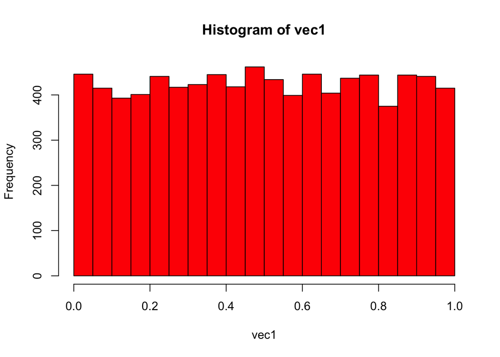

```r
hist(vec1, col = "red")
```

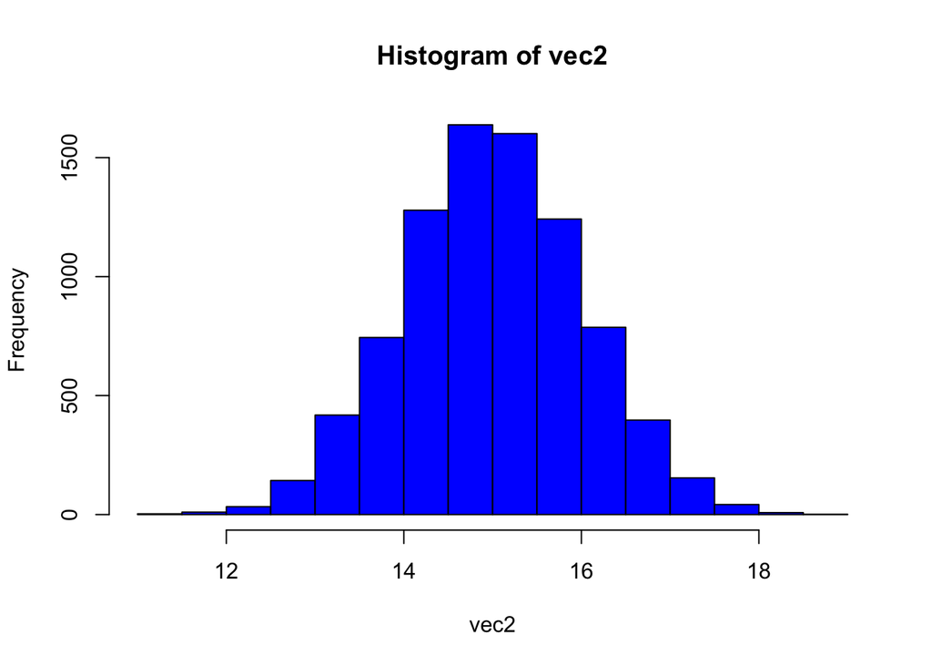

```r
hist(vec2, col = "blue")
```

**3.3 (c)**

```r
CV_1 <- (sd(vec1)/mean(vec1))*100
CV_1
```

```
## [1] 57.50479
```

```r
CV_2 <- (sd(vec2)/mean(vec2))*100
CV_2
```

```
## [1] 6.707985
```

**4.1**

```r
aggregate(PlantGrowth$weight, by=list(PlantGrowth$group), FUN=sd)
```

```
##   Group.1         x
## 1    ctrl 0.5830914
## 2    trt1 0.7936757
## 3    trt2 0.4425733
```

**4.2**

```r
aggregate(PlantGrowth$weight, by=list(PlantGrowth$group), FUN=CI95)
```

```
##   Group.1           x
## 1    ctrl 4.67 , 5.39
## 2    trt1 4.17 , 5.15
## 3    trt2  5.25 , 5.8
```

**4.3 (a)**

```r
aggregate(ToothGrowth$len, by=list(ToothGrowth$supp), FUN=var)
```

```
##   Group.1        x
## 1      OJ 43.63344
## 2      VC 68.32723
```

**4.3 (b)**

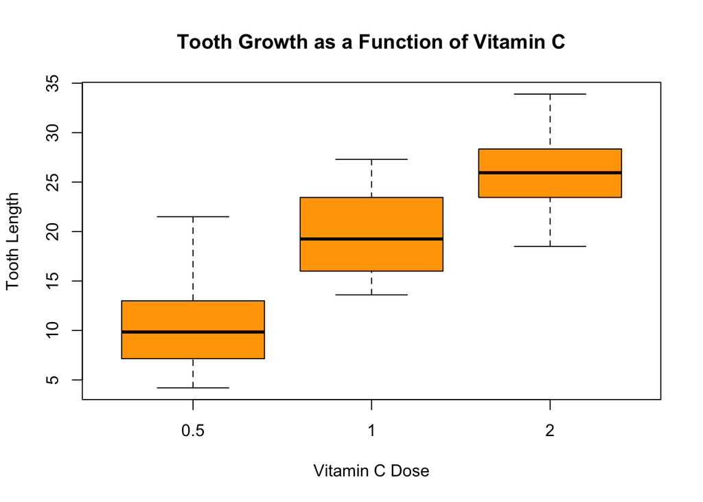

```r
boxplot(ToothGrowth$len ~ ToothGrowth$dose, main = "Tooth Growth as a Function of Vitamin C", xlab = "Vitamin C Dose", ylab = "Tooth Length", col = "orange")
```

The boxplots are not particularly skewed, and appear to be relatively symmetric. We see a correlation between the tooth length and vitamin C dosage, where the higher the dosage, the longer the tooth.

**5.1** It rounds to the nearest whole number.

**5.2**

```r
flips <- 100
round(runif(flips))
```

```
##   [1] 0 1 1 0 0 1 1 1 1 0 1 1 0 0 0 0 0 1 1 1 0 1 1 1 0 1 1 1 1 0 0 0 1 1 0 1 1
##  [38] 0 1 0 0 0 0 0 1 1 0 0 1 0 0 1 0 1 0 1 1 1 1 1 0 0 1 0 0 0 0 0 0 0 1 0 0 1
##  [75] 1 1 0 1 0 0 0 1 0 1 0 1 0 1 1 0 1 1 0 0 1 1 1 1 1 1
```

**5.3** sum(results) gives us the sum of the values generated by runif().

**5.4**

```r
bernoulli <- function(flips, trials){
    result <- numeric(trials)
    for(i in 1:trials){
        tot_head <- sum(round(runif(flips)))
        result[i] <- tot_head/(flips)
    }
    return(result)
}

bernoulli(20,9)
```

```
## [1] 0.45 0.60 0.45 0.40 0.55 0.35 0.60 0.45 0.40
```

**5.5**

[figure not shown]

```r
x <- bernoulli(90, 10)
y <- bernoulli(90, 500)
z <- bernoulli(90, 10000)

hist(x, main = "90 Coins Over 500 Number of Trials", xlab = "Frequency of Heads", col = "green")
```

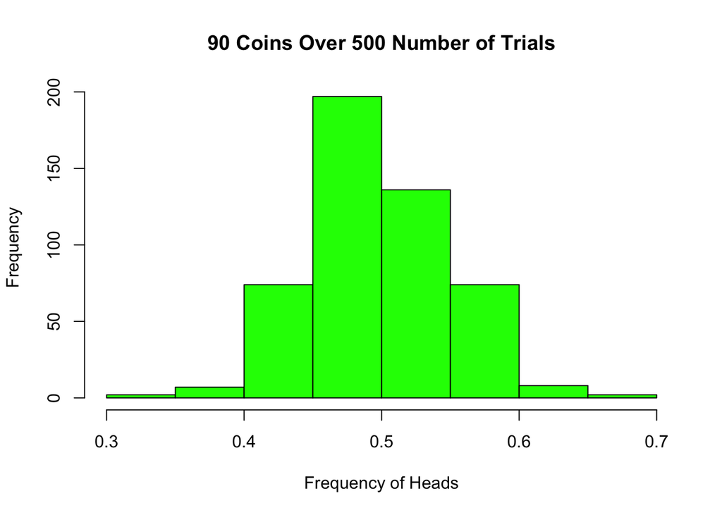

```r
hist(y, main = "90 Coins Over 500 Number of Trials", xlab = "Frequency of Heads", col = "green")
```

[figure not shown]

```r
hist(z, main = "90 Coins Over 500 Number of Trials", xlab = "Frequency of Heads", col = "green")
```

**5.6**

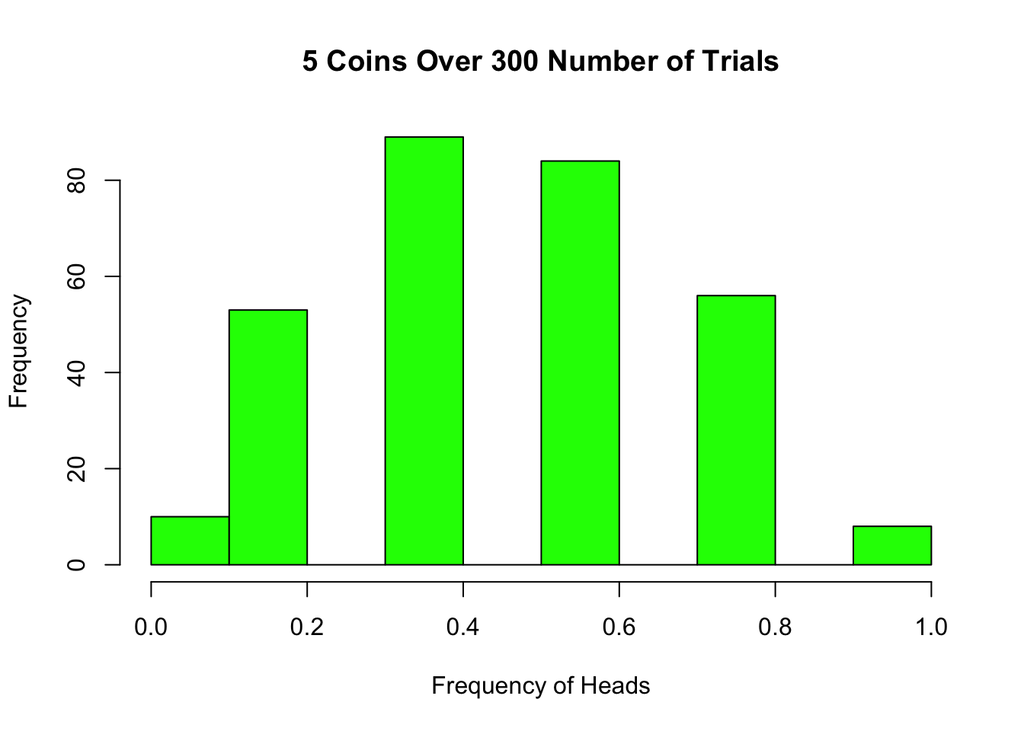

```r
a <- bernoulli(5, 300)
b <- bernoulli(90, 300)
c <- bernoulli(1000, 300)

hist(a, main = "5 Coins Over 300 Number of Trials", xlab = "Frequency of Heads", col = "green")
```

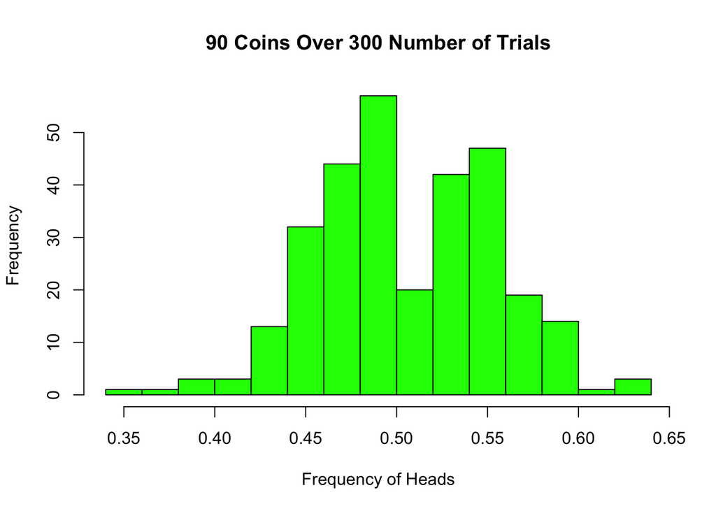

```r
hist(b, main = "90 Coins Over 300 Number of Trials", xlab = "Frequency of Heads", col = "green")
```

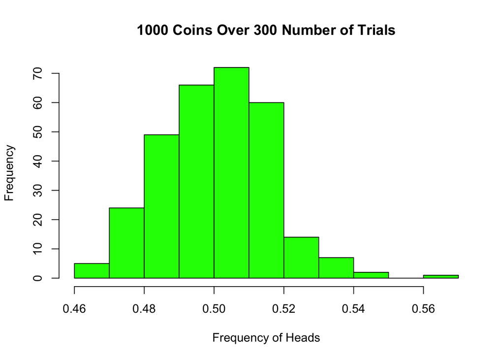

```r
hist(c, main = "1000 Coins Over 300 Number of Trials", xlab = "Frequency of Heads", col = "green")
```

The distribution becomes more Gaussian as the number of coins flipped increases.